# Cervus canadensis - The distance: a proxy for the signal-to-noise ratio

Author

Affiliation

Vincent Arnaud

Université du Québec à Chicoutimi, Canada

Last Update

April 8, 2024

# Sources

> We calculated the signal-to-noise ratio for each 1 s bin in the R programming environment (R Development Core Team, 2017) using a custom function written by D.J.C. that relied heavily on functions in the package ‘seewave’ (Sueur, Aubin, & Simonis, 2008). First, to estimate background noise of the recording, we extracted 1 min before and 1 min after the start of each great call, under the assumption that there would be some portion of the 2 min recording that would contain only background noise (i.e. no gibbon calls or other vocalizing animals). Then, we filtered the files below 450 Hz and above 1800 Hz to focus on the gibbon frequency range. We then divided the 2 min recordings into 1 s bins (each containing 44 100 samples). For each of these 1 s bins we further divided the bin into 100 time slices, each with a duration of 10 ms (441 samples). For each 10 ms slice, we summed the squares of the 441 samples, which provided the in-band power estimate for the 10 ms slice. We then took the median of the 10 ms slice powers for each 1 s bin as an estimate of the noise. This gave us 100 candidate noise estimates (one for each 1 s bin). To calculate a single noise power estimate for each gibbon great call, we used the 10th percentile of the distribution of the candidate noise estimates. To calculate the power value for each 1 s bin of the gibbon call, we filtered the file as outlined above. We then divided the trill into 1 s bins, and further subdivided the bin into 100 time slices, each with a duration of 10 ms (441 samples) and summed the squares of the samples. We then had 100 candidate signal estimates for each 1 s trill bin, of which we used the 75th percentile of those values as our signal power estimate. The 75th percentile estimate still had noise mixed in, so we subtracted our estimated noise power from the power estimate. The signal-to-noise ratio, in decibels, was then computed as SNR dB ¼ 10 x log(signal/noise). We removed all 1 s bins with a signal-to-noise ratio of less than 10 dB from our analyses. R code for calculating signal-to-noise ratio is available as Supplementary material. — Clink et al. (2018)

> We adapted the approach presented in Clink et al. (2018b) to calculate the signal-to-noise ratio of the re-recorded gibbon calls. Our approach used a custom R script written by DJC that relied heavily on the ‘seewave’ package (Sueur et al., 2008). We first filtered the files below 450 Hz and above 1800 Hz to focus on the gibbon frequency range, and then divided each gibbon call into 1-s bins. For each of these 1-s bins we further divided the bin into 100 time slices, each with a duration of 10 ms (480 samples). For each 10 ms slice, we summed the squares of the 480 samples, which provided the in-band power estimate for the 10 ms slice. We then took the median of the 10 ms slice powers for each 1 s bin. To calculate a single noise estimate for each gibbon great call, we used the 10th percentile of the distribution of the 10 ms slices and for the signal we used the 75th percentile. We subtracted our estimated noise value from the signal estimate, as the 75th percentile estimate still contained noise. The signal-to-noise ratio, in decibels, was then computed as signal-to-noise ratio dB = 10 × log(signal/noise). Since we subtracted the noise from the signal value, this allowed for negative signal-to-noise ratio values at greater distances (Clink et al., 2018b). — Lakdari et al. (2024)

# A first version to estimate SNR

In order to estimate the signal-to-noise ratio of the recorded signals at each of the 7 recorder distances from playback speaker, we adopted the approach proposed by Clink et al. (2018) and Lakdari et al. (2024). The `R` code used was adapted from Lakdari et al. (2024). One of the major differences with the proposed method is that to obtain the signal-to-noise ratio at each recorder distance from playback speaker, the 100 recorded vocalizations were concatenated under the assumption that this 292 s recording would contain portions with only background noise.

A strong negative relationship between the signal-to-noise ratio and the recorder distance from the playback speaker is observed (see below). The distance could therefore be an appropriate proxy for the signal-to-noise ratio, as proposed by Lakdari et al. (2024).

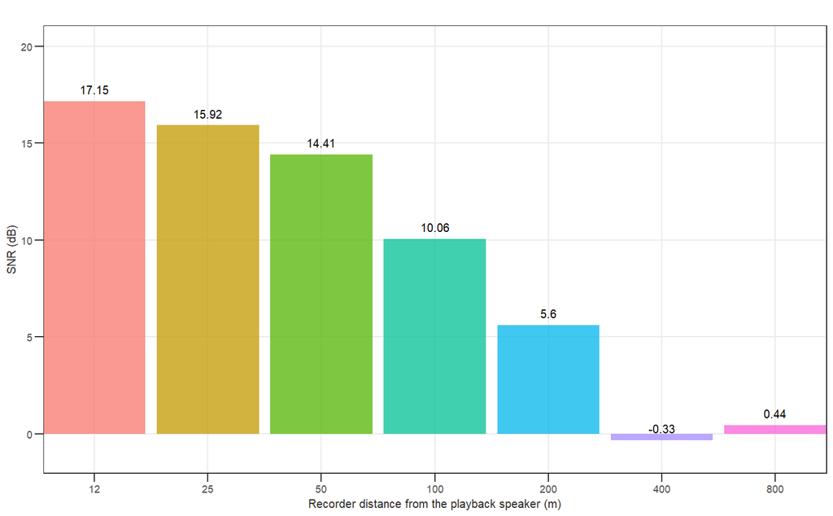

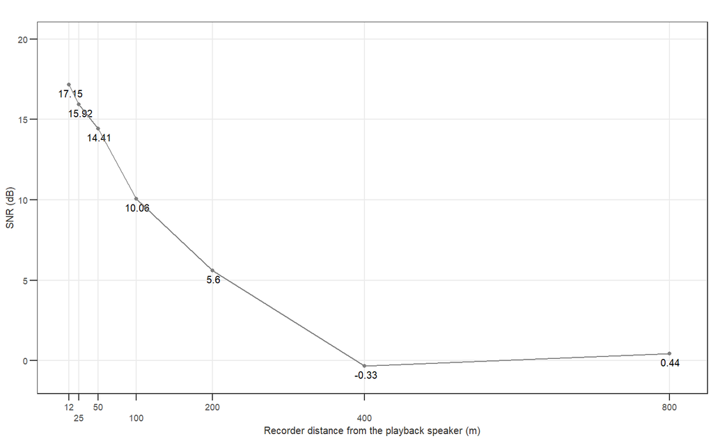

# A second version to estimate SNR

In this second version, the 10 calls of each individual at each distance were concatenated and a individual SNR was estimated at each of the seven distances considered. The mean SNR at each distance shown in the following figures is based on the SNR of each individual at each experimental condition.

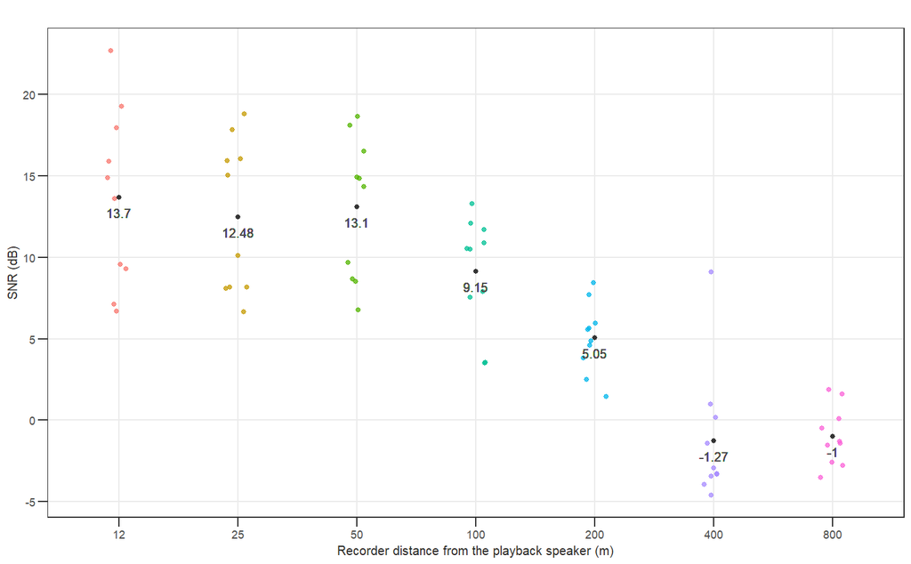

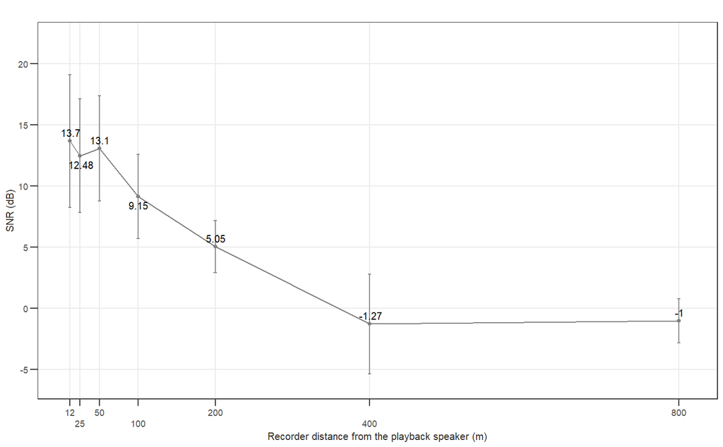

# A third version to estimate SNR

In this third version, each sound bout recorded at each distance was used as input to compute the SNR.

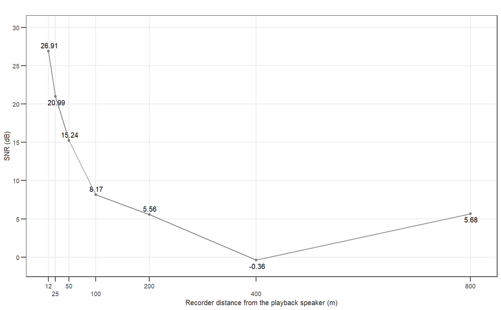

## References

Clink, Dena J., Russell A. Charif, Margaret C. Crofoot, and Andrew J. Marshall. 2018. “Evidence for Vocal Performance Constraints in a Female Nonhuman Primate.” *Animal Behaviour* 141: 85–94. https://doi.org/10.1016/j.anbehav.2018.05.002.

Lakdari, Mohamed Walid, Abdul Hamid Ahmad, Sarab Sethi, Gabriel A. Bohn, and Dena J. Clink. 2024. “Mel-Frequency Cepstral Coefficients Outperform Embeddings from Pre-Trained Convolutional Neural Networks Under Noisy Conditions for Discrimination Tasks of Individual Gibbons.” *Ecological Informatics* 80: 102457. https://doi.org/10.1016/j.ecoinf.2023.102457.